# Projeto Integrador

Felipe Tufaile, Vinicius de Camargo, Caio Cabral, Djalma Saraiva

26/03/2022

### Firm Exiting

The present study aims to build a prediction model for business default. For this purpose, it will be used a database collected and curated by **Bisnode**, an European company in the business information field.  
The database has financial (balance sheet) and operational data of 46.412 companies across Europe, in a variety of segments of the economy, between 2005 and 2016 (the dataset and more information can be accessed directly on the **OSF** website, an open platform to support research and enable collaboration, see bibliographic reference at the end of this document).  
The analysis will be divide in two stages: 1 - Data processing and feature engineering, 2 - Model building. The first stage will be conducted entirely using python programming language in microsoft visual code whereas the second stage will be conducted using R programming language in R Studio.  
Furthermore, the study will consider the following premises and boudary conditions:

- The predictive modeling will be carried out considering the year 2012;
- The company that has defaulted will be the one that does not have sales in 2014;
- The target variable will be the column named **default**: a column created to indicate which companies had no sales in 2014;
- It will be considered companies will total sales, in 2012, between 1 thousand and 1 million euros;

### Setting Global Variables

```r
knitr::opts_chunk$set(echo = TRUE, warning = FALSE, include = TRUE, message = FALSE)
```

### Installing Libraries

```r
# INSTALLING LIBRARIES
# install.packages("vip")
# install.packages('skimr')
# install.packages('GGally')
# install.packages("pdp")
# install.packages("vip")
# install.packages("vip")
# install.packages("glmnet")
# install.packages('caret')
# install.packages("rpart")
# install.packages("ggpubr")
# install.packages("ranger")
# install.packages("janitor")
# install.packages("xgboost")
# install.packages("forcats")
# install.packages("gbm")
```

### Loading Libraries

```r
# IMPORTING LIBRARIES
library(tidyverse)
library(skimr)
library(GGally)
library(ggplot2)
library(caret)
library(vip)
library(pdp)
library(glmnet)
library(rpart)
library(rpart.plot)
library(ggpubr)
library(ranger)
library(reshape2)
library(dplyr)
library(janitor)
library(pROC)
library(DALEX)
library(xgboost)
library(rsample)
library(forcats)
library(gbm)
```

### Data Loading

Loading the processed dataset. The processed dataset has 171 columns (features) in total. Among these columns, the **default** column will be used as explained variable and the **comp_id** column will be removed from modeling since it is only used as an campany identification column and shouldn’t provide any information regarding company defaulting. In summary, the adjusted dataset has 21.717 companies (observations), among which 949 will default in 2014 (4,4% of positive observations) and 20.768 are operational in 2014 (95,6% of negative observations). **Therefore, it is evident that the dataset is unbalanced, with many more negative than positive observations.**  
The command **skim(bisnode)** will be commented so it will not print the extensive list of columns used in modeling. It can be uncommented if there is a need to understand some feature.

```r
# Reading dataset "bisnode_ajustado_completo_2012.csv"
bisnode <- read_csv("bisnode_ajustado_completo_2012.csv")

# Adjusting feature's name
bisnode <- clean_names(bisnode)

# Printing a resumed evaluation of the dataset
# skim(bisnode)

# Remove column "comp_id"
bisnode <- bisnode %>% select(-comp_id)
```

### Separating the Dataset: 80% Train e 20% Test

The following models will be evaluated for the purpose of the study:

- Logistic Regression
- Lasso Regularization
- Random Forest
- GBM - Adaboost
- XGBoost - Binary Logistic

In order to do so, we will first divide the dataset into two sets:training (80% of the observations) and testing (20% of the observations).  
For all dataset splitting throughout this work it will be fixed **seed(0)** so all the same training and test set are used for all models.  
After splitting, the training set has 17.373 samples observations and the testing set has 4.344 observations.

```r
# Setting a seed to fix a random sequence | for reproducibility purposes
set.seed(0)

# Splitting the dataset into training and testing
splits <- initial_split(bisnode, prop = 0.8, strata=default)
# Training data
dt_tr <- training(splits)
# Test data
dt_tt <- testing(splits)
```

### Creating a “Result” Dataframe

A **Result** table will be created in order to hold some key performance metrics calculated for each model in order to facilitate comparisons between the performance of each model.

```r
results <- tibble(model = c("LR", "LR Lasso", "RF", "GBM", "XGB"),
                  lambda_value = c(0, 0, 0, 0, 0),
                  accuracy = c(0, 0, 0, 0, 0),
                  precision = c(0, 0, 0, 0, 0),
                  recall = c(0, 0, 0, 0, 0),
                  f1_score = c(0, 0, 0, 0, 0),
                  auc = c(0, 0, 0, 0, 0))
```

### Function Definition

The following function creates a series of evaluation metrics that will be used to measure the performance of each model. The metrics calculated are:

- Number of **True Positive**;
- Number of **False Positive**;
- Number of **True Negative**;
- Number of **False Negative**;
- **Accuracy**;
- **Precision**;
- **Recall**;
- **F1 Score**;
- **True Positive Rate** / **Sensitivity**;
- **True Negative Rate** / **Specificity**;
- **False Positive Rate**;
- **False Negative Rate**;
- **Custom Metric**;

The custom metric in the final bullet account for a business metric that attempts to capture business interests. It is an additional metric among the traditional metrics. For the context of this study it will be considered that the predictions made will be used in order to decide whether or not to lend money to a company: if the model predicts a company will be operational in 2014 the model would suggest to lend money to that company, otherwise, the model would suggest to not lend money to the company. It will also me assumed that lending money to a company that doesn’t default results 30% of profit, whereas lending money to a company that defaults results a loss of 100% of the lent money. Also, it will be considered that not lending money to a company that does not defaults results a cost of opportunity of 30%, in other words, it means that the business could have profited 30% of the lent money. Taken the premises stated into consideration, the custom metric will be defined according as follows:

- A **True Positive** prediction results 00,0% of profit;
- A **True Negative** prediction results 30,0% of profit;
- A **False Positive** prediction results -30,0% of loss;
- A **False Negative** prediction results -100,0% of loss;

Custom Metric = $\frac{0.3[True Negative] -0.3[False Positive] -1[False Negative]}{[False Negative] + [False Positive] + [True Negative] + [True Positive]}$

The business objective will be to find the model and threshold that maximizes the value of the custom metric.

Although it is also being calculated a custom metric to account for business strategies, **the study will be conducted with the main objective of finding the model a model that maximizes the F1 Score**, which is more appropriate for an unbalanced dataset. In the last section the study will make a consideration about the customized metric.

```r
# Creating a function for evaluating precision for different thresholds
metrics_table <- function(threshold, val_vector, pred_vector) {

  # Classification
  pred_class <- ifelse(pred_vector >= threshold, 1, 0)

  # Calculate True Positive
  true_positive <- sum(ifelse(val_vector + pred_class == 2, 1, 0))

  # Calculate True Negative
  true_negative <- sum(ifelse(val_vector + pred_class == 0, 1, 0))

  # Calculate False Positive
  false_positive <- sum(ifelse(val_vector + pred_class == 1 & pred_class == 1, 1, 0))

  # Calculate False Negative
  false_negative <- sum(ifelse(val_vector + pred_class == 1 & pred_class == 0, 1, 0))

  # Calculate Accuracy
  accuracy <- (true_positive + true_negative) / (true_positive + true_negative + false_positive + false_negative)

  # Calculate Precision
  precision <- true_positive / (true_positive + false_positive)

  # Calculate recall
  recall <- true_positive / (true_positive + false_negative)

  # Calculate F1 Score
  f1_score <- 2*precision*recall / (precision + recall)

  # Calculate True Positive Rate (TPR) | Sensitivity  -> TP / Actual Positive
  tpr <- true_positive / (true_positive + false_negative)

  # Calculate True Negative Rate (TNR) | Specificity  -> TN / Actual Negative
  tnr <- true_negative / (false_positive + true_negative)

  # Calculate False Negative Rate (FNR) -> FN / Actual Positive
  fnr <- false_negative / (true_positive + false_negative)

  # Calculate False Positive Rate (FPR) -> FP / Actual Negative
  fpr <- false_positive / (true_negative + false_positive)

  # Customized metric in order to account for business strategy
  custom_metric <- ((0.3)*true_negative + (-1)*false_negative + (0)*true_positive + (-0.3)*false_positive)
  custom_metric <- custom_metric / (true_positive + true_negative + false_positive + false_negative)

  metrics <- tibble(metric = c("True Positive (TP)",
                               "True Negative (TN)",
                               "False Positive (FP)",
                               "False Negative (FN)",
                               "Accuracy",
                               "Precision",
                               "Recall",
                               "F1 Score",
                               "True Positive Rate (TPR)",
                               "True Negative Rate (TNR)",
                               "False Negative Rate (FNR)",
                               "False Positive Rate (FPR)",
                               "Sensitivity",
                               "Specificity",
                               "Custom Metric"),
                    values = c(0,0,0,0,0,0,0,0,0,0,0,0,0,0,0))

  metrics$values[metrics$metric == "True Positive (TP)"] <- true_positive
  metrics$values[metrics$metric == "True Negative (TN)"] <- true_negative
  metrics$values[metrics$metric == "False Positive (FP)"] <- false_positive
  metrics$values[metrics$metric == "False Negative (FN)"] <- false_negative
  metrics$values[metrics$metric == "Accuracy"] <- accuracy
  metrics$values[metrics$metric == "Precision"] <- precision
  metrics$values[metrics$metric == "Recall"] <- recall
  metrics$values[metrics$metric == "F1 Score"] <- f1_score
  metrics$values[metrics$metric == "True Positive Rate (TPR)"] <- tpr
  metrics$values[metrics$metric == "True Negative Rate (TNR)"] <- tnr
  metrics$values[metrics$metric == "False Negative Rate (FNR)"] <- fnr
  metrics$values[metrics$metric == "False Positive Rate (FPR)"] <- fpr
  metrics$values[metrics$metric == "Sensitivity"] <- tpr
  metrics$values[metrics$metric == "Specificity"] <- tnr
  metrics$values[metrics$metric == "Custom Metric"] <- custom_metric

  # Calculate
  return (metrics)
}
```

### Logistic Regression

The logistic regression model will be performed using the **glm** function with a **binomial** family. The explained variable will be the binary variable **default**, as explained in previous sections.

```r
# Creating a logistic regression model considering all features from the training dataset (dt_tr) but the default feature (target feature)
model_lg <- glm(default ~ ., dt_tr, family = "binomial")

# Prediction of satisfied clients for the training set
yhat_lg_tr <- predict(model_lg, dt_tr, type="response")

# Prediction of satisfied clients for the test set
yhat_lg_tt <- predict(model_lg, dt_tt, type="response")

# Table of metrics for plotting
table_lg <- tibble(threshold = c(seq(0, 1, 0.01)),
                   true_positive_rate = NA,
                   false_positive_rate = NA,
                   accuracy = NA,
                   precision = NA,
                   recall = NA,
                   f1_score = NA)

# Calculate metrics for varying thresholds
for ( t in c(seq(0.0, 1, 0.01)) ){

  tb <- metrics_table(t, dt_tt$default,yhat_lg_tt)

  table_lg$true_positive_rate[table_lg$threshold == t]   <- tb$values[tb$metric == "True Positive Rate (TPR)"]
  table_lg$false_positive_rate[table_lg$threshold == t]  <- tb$values[tb$metric == "False Positive Rate (FPR)"]
  table_lg$accuracy[table_lg$threshold == t]             <- tb$values[tb$metric == "Accuracy"]
  table_lg$precision[table_lg$threshold == t]            <- tb$values[tb$metric == "Precision"]
  table_lg$recall[table_lg$threshold == t]               <- tb$values[tb$metric == "Recall"]
  table_lg$f1_score[table_lg$threshold == t]             <- tb$values[tb$metric == "F1 Score"]

}

table_lg <- table_lg[complete.cases(table_lg), ]


# Calculating Optimal Threshold
opt_threshold <- table_lg$threshold[table_lg$f1_score == max(table_lg$f1_score, na.rm = TRUE)]
opt_tpr <- table_lg$true_positive_rate[table_lg$f1_score == max(table_lg$f1_score, na.rm = TRUE)]

# Table filtering considering the optimal threshold as the value that maximizes the metric F1-Score
table_lg %>% filter(table_lg$threshold == opt_threshold)
```

| threshold | true_positive_rate | false_positive_rate | accuracy | precision | recall | f1_score |
| --- | --- | --- | --- | --- | --- | --- |
| 0.19 | 0.4262295 | 0.0384523 | 0.9389963 | 0.3277311 | 0.4262295 | 0.3705463 |

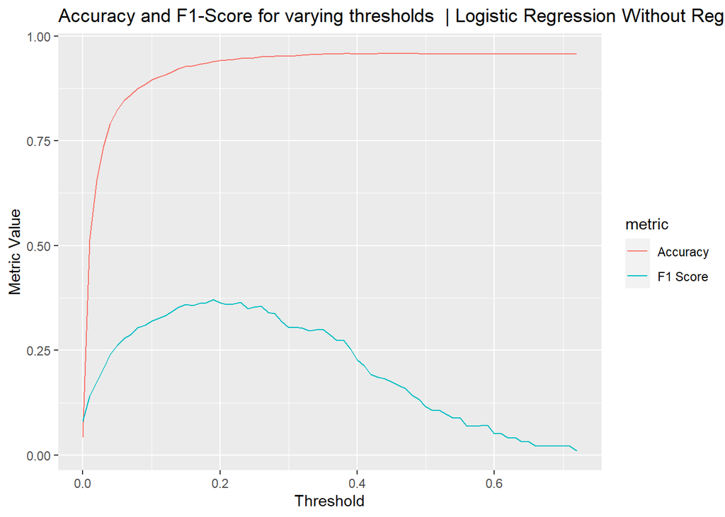

```r
# Creating selections
table_lg %>%
  select(threshold, accuracy) %>%
  dplyr::rename(value = accuracy) %>%
  mutate(metric = "Accuracy") %>%
# Binding rows
bind_rows(
    table_lg %>%
    select(threshold, f1_score) %>%
      dplyr::rename(value = f1_score) %>%
      mutate(metric = "F1 Score")) %>%
        # Plotting
        ggplot(aes(x=threshold, y=value, group = metric, color = metric)) +
        geom_line() +
        ggtitle("Accuracy and F1-Score for varying thresholds  | Logistic Regression Without Regularization") +
        xlab("Threshold") +
        ylab("Metric Value")
```

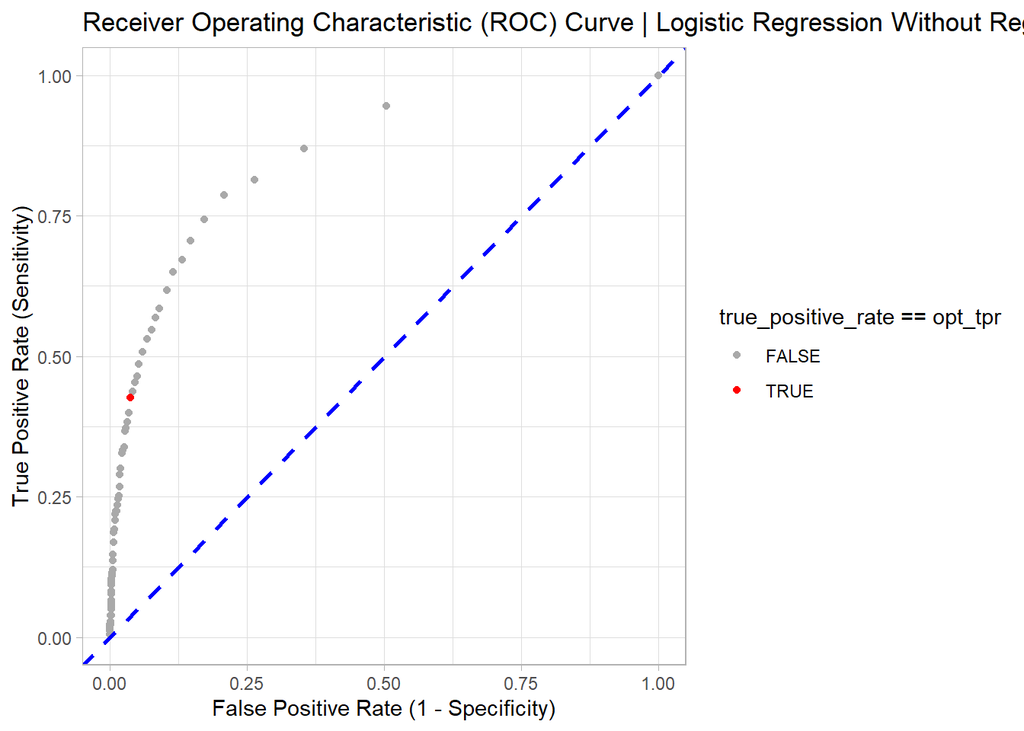

```r
# Plotting ROC Curve
table_lg %>%
  ggplot(aes(x=false_positive_rate, y=true_positive_rate, color = true_positive_rate == opt_tpr)) +
  geom_point() +
  scale_color_manual(values = c("FALSE" = "darkgray", "TRUE" = "red")) +
  geom_abline(intercept = 0, slope = 1, color="blue", linetype="dashed", size=1.0) +
  ggtitle("Receiver Operating Characteristic (ROC) Curve | Logistic Regression Without Regularization") +
  xlim(0, 1) +
  ylim(0, 1) +
  xlab("False Positive Rate (1 - Specificity)") +
  ylab("True Positive Rate (Sensitivity)") +
  theme_light()
```

The result table bellow shows the summary performance of the logistic regression model. The **F1 Score** value and the **AUC** value are, **0.371** and **0.863**, respectively. In the sequence, the confusion matrix for the logistic regression model is shown in order to indicate the number of observations the model have predicted in the wrong class.

```r
# Updating results table
results$accuracy[results$model == "LR"]  <- table_lg$accuracy[table_lg$f1_score == max(table_lg$f1_score)]
results$precision[results$model == "LR"] <- table_lg$precision[table_lg$f1_score == max(table_lg$f1_score)]
results$recall[results$model == "LR"]    <- table_lg$recall[table_lg$f1_score == max(table_lg$f1_score)]
results$f1_score[results$model == "LR"]  <- table_lg$f1_score[table_lg$f1_score == max(table_lg$f1_score)]
results$auc[results$model == "LR"]       <- roc(dt_tt$default, yhat_lg_tt)$auc
results
```

| model | lambda_value | accuracy | precision | recall | f1_score | auc |
| --- | --- | --- | --- | --- | --- | --- |
| LR | 0 | 0.9389963 | 0.3277311 | 0.4262295 | 0.3705463 | 0.8626709 |
| LR Lasso | 0 | 0.0000000 | 0.0000000 | 0.0000000 | 0.0000000 | 0.0000000 |
| RF | 0 | 0.0000000 | 0.0000000 | 0.0000000 | 0.0000000 | 0.0000000 |
| GBM | 0 | 0.0000000 | 0.0000000 | 0.0000000 | 0.0000000 | 0.0000000 |
| XGB | 0 | 0.0000000 | 0.0000000 | 0.0000000 | 0.0000000 | 0.0000000 |

```r
# Plotting Confusion Matrix
cmt_lg <- metrics_table(opt_threshold, dt_tt$default, yhat_lg_tt)
confusion_matrix_lg <- tibble(x = c("Actual Positive", "Actual Negative"),
                           y = c(cmt_lg$values[cmt_lg$metric == "True Positive (TP)"],
                                 cmt_lg$values[cmt_lg$metric == "False Positive (FP)"]),
                           z = c(cmt_lg$values[cmt_lg$metric == "False Negative (FN)"],
                                 cmt_lg$values[cmt_lg$metric == "True Negative (TN)"]))
knitr::kable(confusion_matrix_lg,
             caption = "Confusion Matrix | Logistic Regression Without Regularization",
             col.names = c("Measure", "Predicted Positive", "Predicted Negative"))
```

Confusion Matrix | Logistic Regression Without Regularization

| Measure | Predicted Positive | Predicted Negative |
| --- | --- | --- |
| Actual Positive | 78 | 105 |
| Actual Negative | 160 | 4001 |

### Logistic Regression With Lasso Regularization

The logistic regression model With Lasso Regularization will be performed using the **glm** function with a **binomial** family and setting **alpha** to 1. The regularization parameter, **$\lambda$**, will be obtained through cross-validation using function **cv.glmnet**. he resulting **$\lambda$** value is, approximately, **0.00435**. It can be seen, in the following plot, the the chosen value for **$\lambda$** results a reduction in the number of features from 169 to 24, a significant reduction. That indicates that many features in the dataset (nearly 86% of the features) doesn’t really seems to have an important role in explaning the default behaviour.

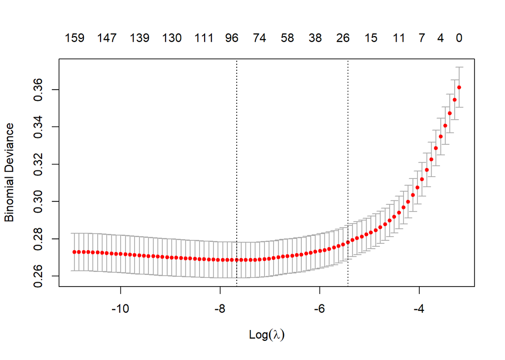

```r
# Preparing the model for gmlet
# Selecting train
X_tr <- model.matrix(default~., dt_tr)
y_tr <- dt_tr$default

# Selecting test
X_tt <- model.matrix(default~., dt_tt)
y_tt <- dt_tt$default

# LASSO -> Logistic Regression (family=binomial, alpha=1)

# Build a model with regularization with varying 500 lambdas
lg_lasso <- glmnet(X_tr, y_tr, family="binomial", alpha = 1, nlambda = 500)

# Preforming Cross Validation (CV) in order to determine the best lambda
cv_lasso <- cv.glmnet(X_tr, y_tr, family="binomial", alpha=1)

# Optimal lambda
opt_lambda_lasso <- cv_lasso$lambda.1se

# Plotting the model for varying lambda
plot(cv_lasso)
```

```r
# Calculating the predictions using the regularized model after cross-validation | Training
yhat_lg_lasso_tr <- predict(cv_lasso, newx = X_tr, s = opt_lambda_lasso, type="response")

# Calculating the predictions using the regularized model after cross-validation | Test
yhat_lg_lasso_tt <- predict(cv_lasso, newx = X_tt, s = opt_lambda_lasso, type="response")

# Table of metrics for plotting
tb_lasso <- tibble(threshold = c(seq(0, 1, 0.01)),
                   true_positive_rate = NA,
                   false_positive_rate = NA,
                   accuracy = NA,
                   precision = NA,
                   recall = NA,
                   f1_score = NA)

# Calculate metrics for varying thresholds
for ( t in c(seq(0, 1, 0.01)) ){

  tb <- metrics_table(t, dt_tt$default, yhat_lg_lasso_tt)

  tb_lasso$true_positive_rate[tb_lasso$threshold == t]   <- tb$values[tb$metric == "True Positive Rate (TPR)"]
  tb_lasso$false_positive_rate[tb_lasso$threshold == t]  <- tb$values[tb$metric == "False Positive Rate (FPR)"]
  tb_lasso$accuracy[tb_lasso$threshold == t]             <- tb$values[tb$metric == "Accuracy"]
  tb_lasso$precision[tb_lasso$threshold == t]            <- tb$values[tb$metric == "Precision"]
  tb_lasso$recall[tb_lasso$threshold == t]               <- tb$values[tb$metric == "Recall"]
  tb_lasso$f1_score[tb_lasso$threshold == t]             <- tb$values[tb$metric == "F1 Score"]

}

tb_lasso <- tb_lasso[complete.cases(tb_lasso), ]

# Calculating Optimal Threshold
opt_threshold_lasso <- tb_lasso$threshold[tb_lasso$f1_score == max(tb_lasso$f1_score, na.rm = TRUE)]
opt_tpr_lasso <- tb_lasso$true_positive_rate[tb_lasso$f1_score == max(tb_lasso$f1_score, na.rm = TRUE)]

# Best Result
tb_lasso %>% filter(tb_lasso$f1_score == max(tb_lasso$f1_score, na.rm = TRUE))
```

| threshold | true_positive_rate | false_positive_rate | accuracy | precision | recall | f1_score |
| --- | --- | --- | --- | --- | --- | --- |
| 0.17 | 0.3606557 | 0.03244412 | 0.941989 | 0.3283582 | 0.3606557 | 0.34375 |

The accuracy and F1-score curves and the ROC curve for the Logistic Regression with Lasso regularization look very similar to the ones obtained to the Logistic Regression without regularization, with no significant changes that is worth mentioning. **The best threshold for the logistic regression model with LASSO is also very close, 0.17**.

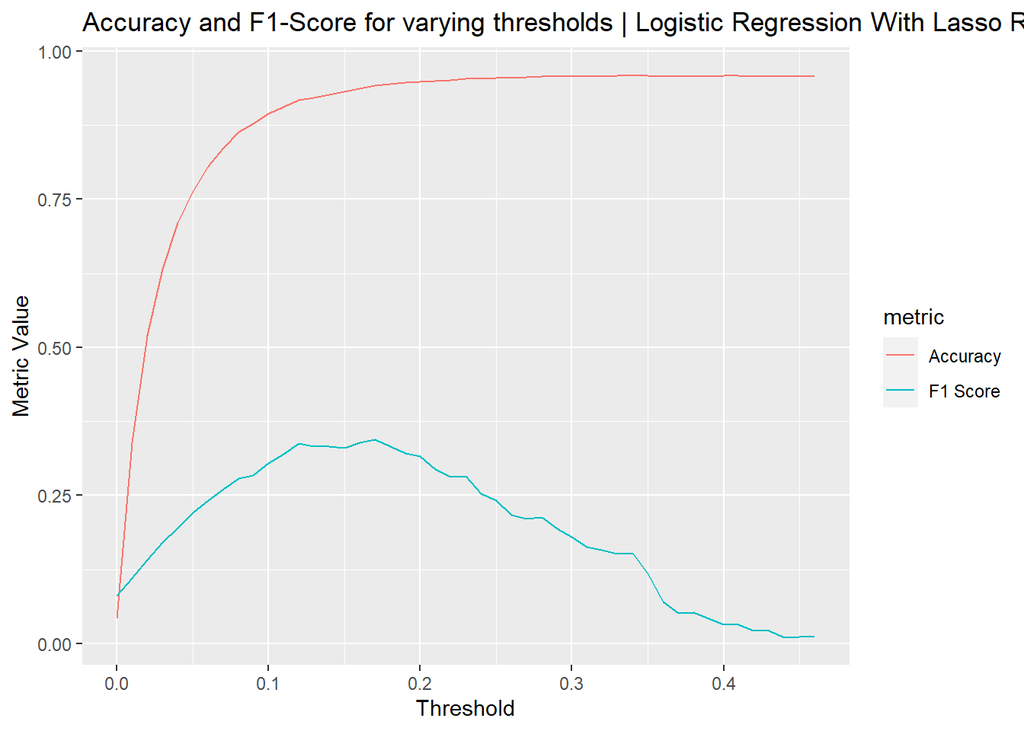

```r
# Creating selections
tb_lasso %>%
  select(threshold, accuracy) %>%
  dplyr::rename(value = accuracy) %>%
  mutate(metric = "Accuracy") %>%
# Binding rows
bind_rows(
    tb_lasso %>%
    select(threshold, f1_score) %>%
      dplyr::rename(value = f1_score) %>%
      mutate(metric = "F1 Score")) %>%
        # Plotting
        ggplot(aes(x=threshold, y=value, group = metric, color = metric)) +
        geom_line() +
        ggtitle("Accuracy and F1-Score for varying thresholds | Logistic Regression With Lasso Regularization") +
        xlab("Threshold") +
        ylab("Metric Value")
```

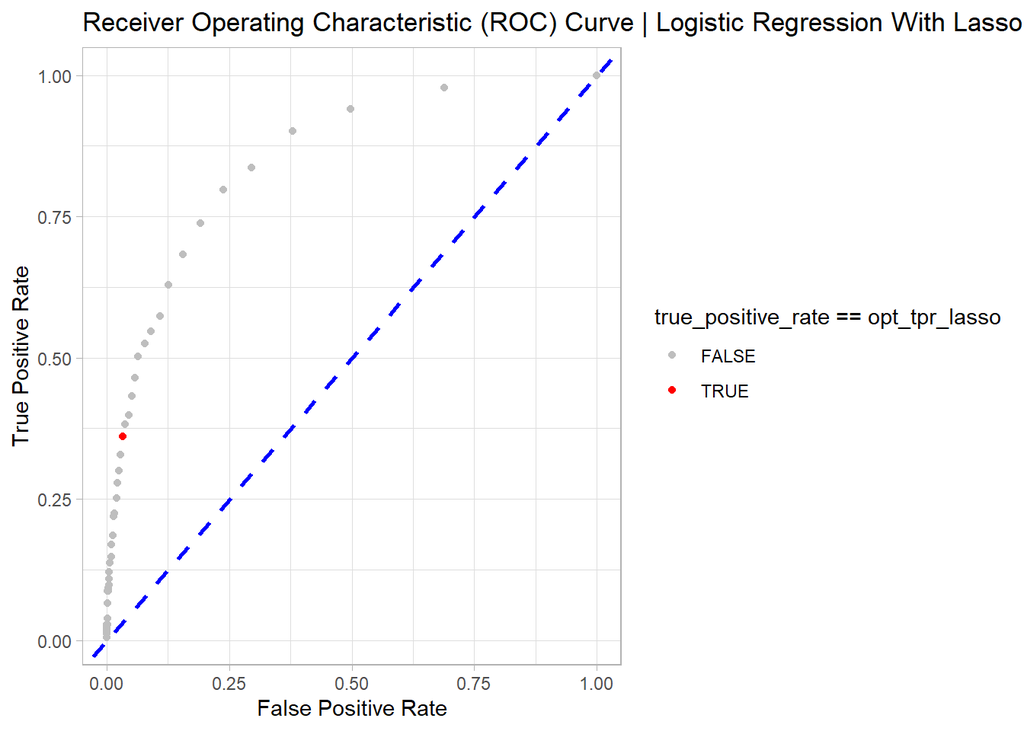

```r
# Plotting ROC Curve
tb_lasso %>%
  ggplot(aes(x=false_positive_rate, y=true_positive_rate, color = true_positive_rate == opt_tpr_lasso)) +
  geom_point() +
  scale_color_manual(values = c("FALSE" = "grey", "TRUE" = "red")) +
  geom_abline(intercept = 0, slope = 1, color="blue", linetype="dashed", size=1.0) +
  ggtitle("Receiver Operating Characteristic (ROC) Curve | Logistic Regression With Lasso Regularization") +
  xlab("False Positive Rate") +
  ylab("True Positive Rate") +
  theme_light()
```

The following result table shows the summary performance of the logistic regression model with LASSO regularization. The **F1 Score** value is **0.344**, slightly lower than the previous model, and the **AUC** value is **0.858**, also slightly lower than the previous model. Therefore, it can be shown that despite the huge reduction in the number of features, the were no much reduction performance, which indicates that, in fact, there is a lot of features doesn’t really explain anything about companies defaulting. In the sequence, the confusion matrix for the logistic regression model with LASSO is shown in order to indicate the number of observations the model have predicted in the wrong class.

```r
# Updating results table
results$accuracy[results$model == "LR Lasso"]     <- tb_lasso$accuracy[tb_lasso$f1_score == max(tb_lasso$f1_score)]
results$precision[results$model == "LR Lasso"]    <- tb_lasso$precision[tb_lasso$f1_score == max(tb_lasso$f1_score)]
results$recall[results$model == "LR Lasso"]       <- tb_lasso$recall[tb_lasso$f1_score == max(tb_lasso$f1_score)]
results$f1_score[results$model == "LR Lasso"]     <- tb_lasso$f1_score[tb_lasso$f1_score == max(tb_lasso$f1_score)]
results$auc[results$model == "LR Lasso"]          <- roc(y_tt, c(yhat_lg_lasso_tt))$auc
results$lambda_value[results$model == "LR Lasso"] <- opt_lambda_lasso
results
```

| model | lambda_value | accuracy | precision | recall | f1_score | auc |
| --- | --- | --- | --- | --- | --- | --- |
| LR | 0.000000000 | 0.9389963 | 0.3277311 | 0.4262295 | 0.3705463 | 0.8626709 |
| LR Lasso | 0.004349642 | 0.9419890 | 0.3283582 | 0.3606557 | 0.3437500 | 0.8583385 |
| RF | 0.000000000 | 0.0000000 | 0.0000000 | 0.0000000 | 0.0000000 | 0.0000000 |
| GBM | 0.000000000 | 0.0000000 | 0.0000000 | 0.0000000 | 0.0000000 | 0.0000000 |
| XGB | 0.000000000 | 0.0000000 | 0.0000000 | 0.0000000 | 0.0000000 | 0.0000000 |

```r
# Plotting Confusion Matrix
cmt_lg_lasso <- metrics_table(opt_threshold_lasso, dt_tt$default, yhat_lg_lasso_tt)
confusion_matrix_lasso <- tibble(x = c("Actual Positive", "Actual Negative"),
                                 y = c(cmt_lg_lasso$values[cmt_lg_lasso$metric == "True Positive (TP)"],
                                       cmt_lg_lasso$values[cmt_lg_lasso$metric == "False Positive (FP)"]),
                                 z = c(cmt_lg_lasso$values[cmt_lg_lasso$metric == "False Negative (FN)"],
                                       cmt_lg_lasso$values[cmt_lg_lasso$metric == "True Negative (TN)"]))
knitr::kable(confusion_matrix_lasso,
             caption = "Confusion Matrix | Logistic Regression with Lasso Regularization",
             col.names = c("Measure", "Predicted Positive", "Predicted Negative"))
```

Confusion Matrix | Logistic Regression with Lasso Regularization

| Measure | Predicted Positive | Predicted Negative |
| --- | --- | --- |
| Actual Positive | 66 | 117 |
| Actual Negative | 135 | 4026 |

### Random Forest Model

The following segment show a first attempt to fit a random forest model in the dataset. In order to do so, it was used the function **ranger** to build models for a range of **mtry** and **num.trees** values in order to determine the optimal value for these two hyperparameters. The following chunck of code performs a grid search for the best values for the hyperparameters mentioned.

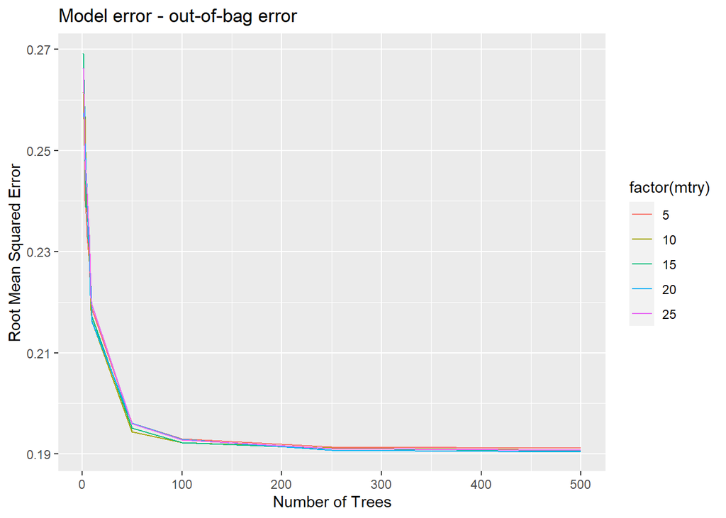

```r
# Creating a function for tuning the hyperparameters of the random forest model
rf_tuning <- function(mtry, n_arvores) {
  fit <- ranger(default ~ .,num.trees = n_arvores, mtry = mtry, data = dt_tr)
  return(sqrt(fit$prediction.error))}

# Simulating random forest models for testing hyperparameters
rf_results <- crossing(mtry = c(seq(5, 25, 5)), n_trees = c(1:10, 50, 100, 250, 500)) %>%
              mutate(rmse = map2_dbl(mtry, n_trees, rf_tuning))

# Plotting results
rf_results %>%
  ggplot(aes(x=n_trees, y=rmse, group = mtry, color = factor(mtry))) +
  geom_line() +
  ggtitle("Model error - out-of-bag error") +
  ylab("Root Mean Squared Error") +
  xlab("Number of Trees")
```

It can be shown in the image above that there is not much significant reduction in loss for all the **mtry** values tested. Also, it can be seen that 500 trees seems to be enough in order for the error to stabilize. For that reason, the best model will be cinfigured with **mtry = 10** and **num.trees = 500**.

```r
# Using the best hyperparameters in order to create the final model
rf_model <- ranger(default ~., mtry = 10, num.trees = 500, importance = "permutation", data = dt_tr)

# Creating predictions using the optimal random forest
yhat_tr_rf <- predict(rf_model, dt_tr)

# Creating predictions using the optimal random forest
yhat_tt_rf <- predict(rf_model, dt_tt)

# Table of metrics for plotting
tb_rf <- tibble(threshold = c(seq(0, 1, 0.01)),
                true_positive_rate = NA,
                false_positive_rate = NA,
                accuracy = NA,
                precision = NA,
                recall = NA,
                f1_score = NA)

# Calculate metrics for varying thresholds
for ( t in c(seq(0, 1, 0.01)) ){

  tb <- metrics_table(t, dt_tt$default, yhat_tt_rf$predictions)

  tb_rf$true_positive_rate[tb_rf$threshold == t]   <- tb$values[tb$metric == "True Positive Rate (TPR)"]
  tb_rf$false_positive_rate[tb_rf$threshold == t]  <- tb$values[tb$metric == "False Positive Rate (FPR)"]
  tb_rf$accuracy[tb_rf$threshold == t]             <- tb$values[tb$metric == "Accuracy"]
  tb_rf$precision[tb_rf$threshold == t]            <- tb$values[tb$metric == "Precision"]
  tb_rf$recall[tb_rf$threshold == t]               <- tb$values[tb$metric == "Recall"]
  tb_rf$f1_score[tb_rf$threshold == t]             <- tb$values[tb$metric == "F1 Score"]
  tb_rf$f1_score[tb_rf$threshold == t]             <- tb$values[tb$metric == "F1 Score"]

}

tb_rf <- tb_rf[complete.cases(tb_rf), ]

# Calculating Optimal Threshold
opt_threshold_rf <- tb_rf$threshold[tb_rf$f1_score == max(tb_rf$f1_score, na.rm = TRUE)][1]
opt_tpr_rf <- tb_rf$true_positive_rate[tb_rf$f1_score == max(tb_rf$f1_score, na.rm = TRUE)][1]

# Best Result
tb_rf %>% filter(tb_rf$threshold == opt_threshold_rf)
```

| threshold | true_positive_rate | false_positive_rate | accuracy | precision | recall | f1_score |
| --- | --- | --- | --- | --- | --- | --- |
| 0.16 | 0.5027322 | 0.06633021 | 0.9155157 | 0.25 | 0.5027322 | 0.3339383 |

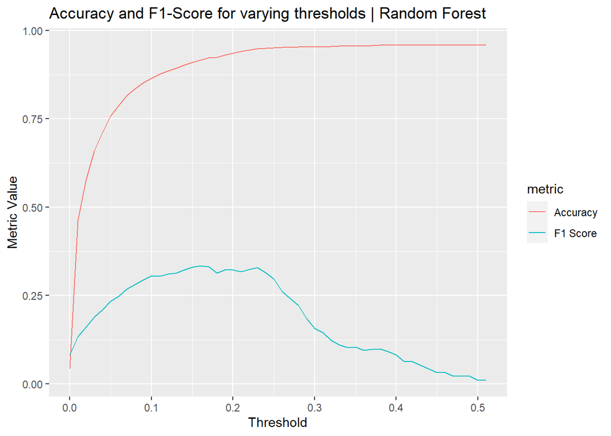

```r
# Creating selections
tb_rf %>%
  select(threshold, accuracy) %>%
  dplyr::rename(value = accuracy) %>%
  mutate(metric = "Accuracy") %>%
# Binding rows
bind_rows(
    tb_rf %>%
    select(threshold, f1_score) %>%
      dplyr::rename(value = f1_score) %>%
      mutate(metric = "F1 Score")) %>%
        # Plotting
        ggplot(aes(x=threshold, y=value, group = metric, color = metric)) +
        geom_line() +
        ggtitle("Accuracy and F1-Score for varying thresholds | Random Forest") +
        xlab("Threshold") +
        ylab("Metric Value")
```

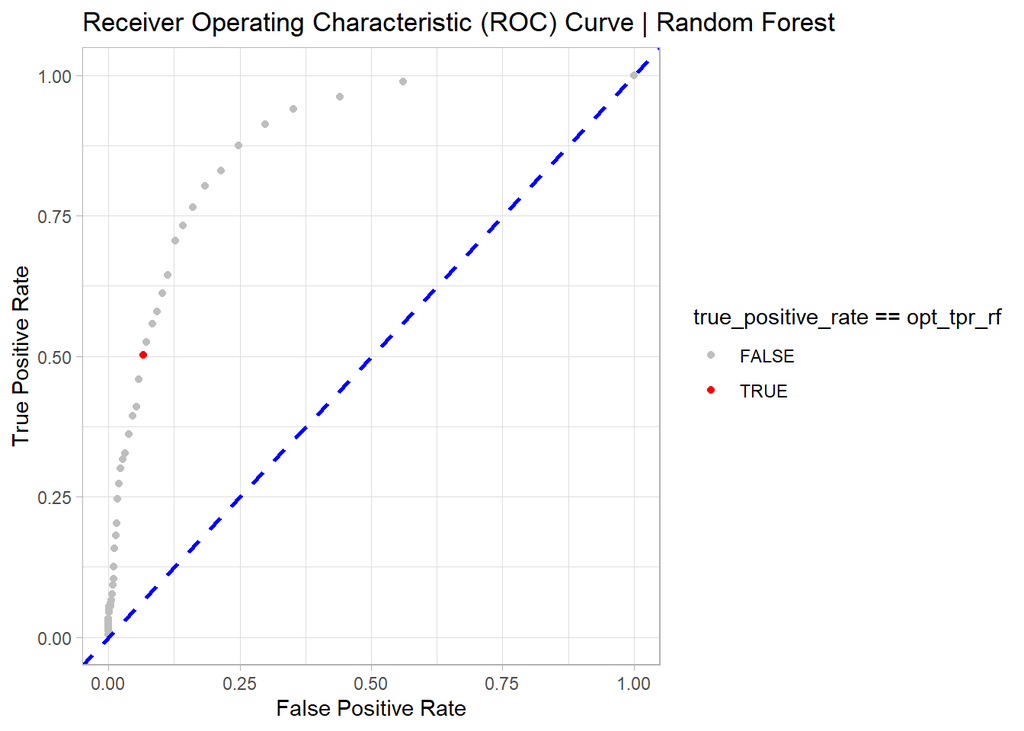

```r
# Plotting ROC Curve
tb_rf %>%
  ggplot(aes(x=false_positive_rate, y=true_positive_rate, color = true_positive_rate == opt_tpr_rf)) +
  geom_point() +
  scale_color_manual(values = c("FALSE" = "grey", "TRUE" = "red")) +
  geom_abline(intercept = 0, slope = 1, color="blue", linetype="dashed", size=1.0) +
  xlim(0, 1) +
  ylim(0, 1) +
  ggtitle("Receiver Operating Characteristic (ROC) Curve | Random Forest") +
  xlab("False Positive Rate") +
  ylab("True Positive Rate") +
  theme_light()
```

```r
# Updating results table
results$accuracy[results$model == "RF"]  <- tb_rf$accuracy[tb_rf$threshold == opt_threshold_rf]
results$precision[results$model == "RF"] <- tb_rf$precision[tb_rf$threshold == opt_threshold_rf]
results$recall[results$model == "RF"]    <- tb_rf$recall[tb_rf$threshold == opt_threshold_rf]
results$f1_score[results$model == "RF"]  <- tb_rf$f1_score[tb_rf$threshold == opt_threshold_rf]
results$auc[results$model == "RF"]       <- roc(dt_tt$default, c(yhat_tt_rf$predictions))$auc
results
```

| model | lambda_value | accuracy | precision | recall | f1_score | auc |
| --- | --- | --- | --- | --- | --- | --- |
| LR | 0.000000000 | 0.9389963 | 0.3277311 | 0.4262295 | 0.3705463 | 0.8626709 |
| LR Lasso | 0.004349642 | 0.9419890 | 0.3283582 | 0.3606557 | 0.3437500 | 0.8583385 |
| RF | 0.000000000 | 0.9155157 | 0.2500000 | 0.5027322 | 0.3339383 | 0.8878862 |
| GBM | 0.000000000 | 0.0000000 | 0.0000000 | 0.0000000 | 0.0000000 | 0.0000000 |
| XGB | 0.000000000 | 0.0000000 | 0.0000000 | 0.0000000 | 0.0000000 | 0.0000000 |

```r
# Plotting Confusion Matrix
cmt_lg_rf <- metrics_table(opt_threshold_rf, dt_tt$default, yhat_tt_rf$predictions)
confusion_matrix_rf <- tibble(x = c("Actual Positive", "Actual Negative"),
                                 y = c(cmt_lg_rf$values[cmt_lg_rf$metric == "True Positive (TP)"],
                                       cmt_lg_rf$values[cmt_lg_rf$metric == "False Positive (FP)"]),
                                 z = c(cmt_lg_rf$values[cmt_lg_rf$metric == "False Negative (FN)"],
                                       cmt_lg_rf$values[cmt_lg_rf$metric == "True Negative (TN)"]))
knitr::kable(confusion_matrix_rf,
             caption = "Confusion Matrix | Random Forest",
             col.names = c("Measure", "Predicted Positive", "Predicted Negative"))
```

Confusion Matrix | Random Forest

| Measure | Predicted Positive | Predicted Negative |
| --- | --- | --- |
| Actual Positive | 92 | 91 |
| Actual Negative | 276 | 3885 |

### GBM - Adaboost

In the next section it will be studied the first boosting model with the aid of the **GBM** library. Since the analysis deals with a classification problem, the algorithm used with the **GBM** function will be the **Adaboost** algorithm. Therefore, the **distribution** parameter of the function will be set to **adaboost**. For the purpose of tuning the GBM - Adaboost model, it will be created a grid search varying the following parameters:

- **shrinkage**: the learning rate of the gradient descent algorithm;
- **n.trees**: the number of trees used in the adaboost algorithm;
- **interaction.depth**: the depth of each tree used in the adaboost algorithm;
- **bag.fraction**: the fraction of observations used in each tree. When less than one it means that is being performed a stochastic gradient descent approach;

```r
# Performing grid search in order to find the best combination of hyperparameters
# create hyperparameter grid
hyper_grid <- expand.grid(
  shrinkage = c(0.01, 0.1),
  n.trees = c(seq(1,10,1), 50, 100, 500, 1000, 2000, 3000, 4000, 5000),
  interaction.depth = c(1, 5, 9),
  n.minobsinnode = 10,
  bag.fraction = c(0.6, 0.8, 1),
  auc = 0                    # a place to hold calculated aucs
)


# Splitting the training set into training and validation set
# The reason we do that instead of performing cross-validation is to speed-up the hyperparameter tuning
val_splits <- initial_split(dt_tr, prop = 0.75, strata=default)
# Training data
val_dtr <- training(val_splits)
# Test data
val_dtt <- testing(val_splits)

# grid search
for(i in 1:nrow(hyper_grid)) {

  # train model
  fit <- gbm(
    formula = default ~ .,
    distribution = "adaboost",
    data = val_dtr,
    n.trees = hyper_grid$n.trees[i],
    interaction.depth = hyper_grid$interaction.depth[i],
    shrinkage = hyper_grid$shrinkage[i],
    n.minobsinnode = hyper_grid$n.minobsinnode[i],
    bag.fraction = hyper_grid$bag.fraction[i],
    n.cores = NULL, # will use all cores by default
    verbose = FALSE
  )

  # Add min training error and trees to grid
  yhat_tt_val_gbm <- predict(fit, newdata = val_dtt, n.trees = hyper_grid$n.trees[i], type = "response")

  # Updating hyper_grid
  hyper_grid$auc[i] <- roc(val_dtt$default, yhat_tt_val_gbm)$auc
}
```

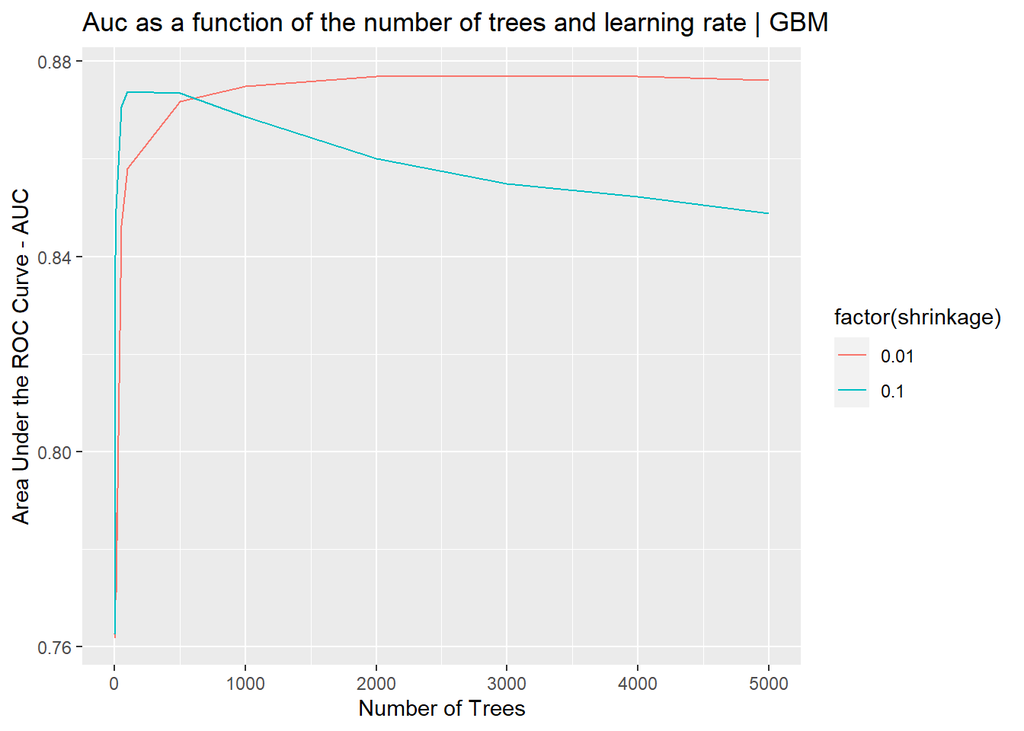

```r
# Plotting F1-Score as a function of the number of trees and learning rate GBM
hyper_grid %>%
  group_by(n.trees, shrinkage) %>%
  summarise(auc_mean = mean(auc)) %>%
  ggplot(aes(x=n.trees, y=auc_mean, group = shrinkage, color = factor(shrinkage))) +
  geom_line() +
  ggtitle("Auc as a function of the number of trees and learning rate | GBM") +
  ylab("Area Under the ROC Curve - AUC") +
  xlab("Number of Trees")
```

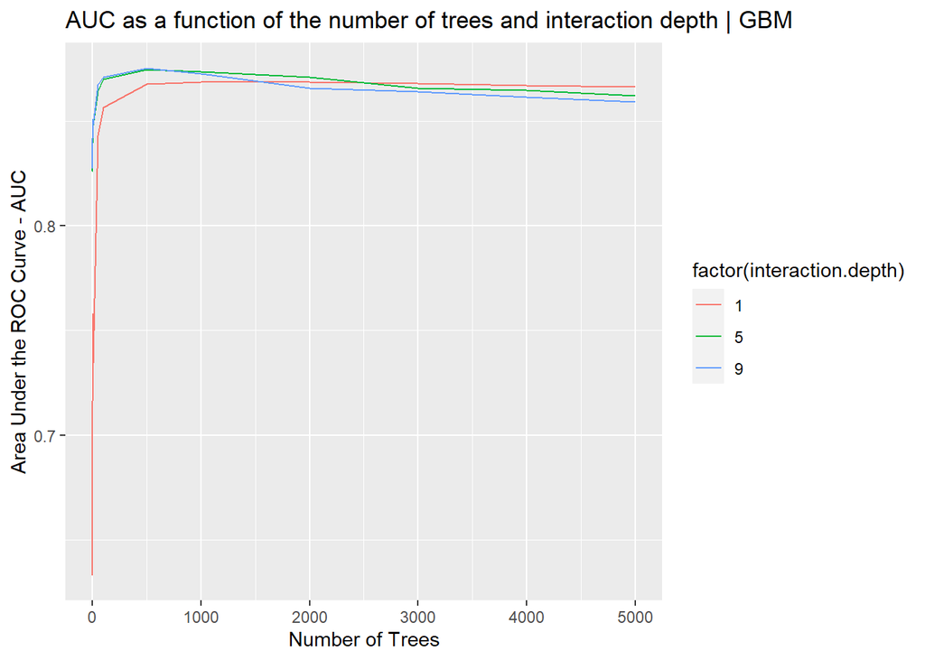

```r
# Plotting F1-Score as a function of the number of trees and interaction depth GBM
hyper_grid %>%
  group_by(n.trees, interaction.depth) %>%
  summarise(auc_mean = mean(auc)) %>%
  ggplot(aes(x=n.trees, y=auc_mean, group = interaction.depth, color = factor(interaction.depth))) +
  geom_line() +
  ggtitle("AUC as a function of the number of trees and interaction depth | GBM") +
  ylab("Area Under the ROC Curve - AUC") +
  xlab("Number of Trees")
```